# Midterm 2 W25

William Holley

2025-03-04

## Instructions

Before starting the exam, you need to follow the instructions in `02_midterm2_cleaning.Rmd` to clean the data. Once you have cleaned the data and produced the `heart.csv` file, you can start the exam.

Answer the following questions and complete the exercises in RMarkdown. Please embed all of your code and push your final work to your repository. Your code must be organized, clean, and run free from errors. Remember, you must remove the `#` for any included code chunks to run. Be sure to add your name to the author header above.

Your code must knit in order to be considered. If you are stuck and cannot answer a question, then comment out your code and knit the document. You may use your notes, labs, and homework to help you complete this exam. Do not use any other resources- including AI assistance or other students’ work.

Don’t forget to answer any questions that are asked in the prompt! Each question must be coded; it cannot be answered by a sort in a spreadsheet or a written response.

All plots should be clean, with appropriate labels, and consistent aesthetics. Poorly labeled or messy plots will receive a penalty. Your plots should be in color and look professional!

Be sure to push your completed midterm to your repository and upload the document to Gradescope. This exam is worth 30 points.

## Load the libraries

You may not use all of these, but they are here for convenience.

```r
library("tidyverse")
library("janitor")
library("ggthemes")
library("RColorBrewer")
library("paletteer")
```

## Load the data

These data are a modified version of the Statlog (Heart) database on heart disease from the [UCI Machine Learning Repository](https://archive.ics.uci.edu/dataset/145/statlog+heart). The data are also available on [Kaggle](https://www.kaggle.com/datasets/ritwikb3/heart-disease-statlog/data).

You will need the descriptions of the variables to answer the questions. Please reference `03_midterm2_descriptions.Rmd` for details.

Run the following to load the data.

```r
heart <- read_csv("data/heart.csv")
```

## Questions

Problem 1. (1 point) Use the function of your choice to provide a data summary.

```r
summary(heart)
```

```
##       age           gender               cp               trestbps
##  Min.   :29.00   Length:270         Length:270         Min.   : 94.0
##  1st Qu.:48.00   Class :character   Class :character   1st Qu.:120.0
##  Median :55.00   Mode  :character   Mode  :character   Median :130.0
##  Mean   :54.43                                         Mean   :131.3
##  3rd Qu.:61.00                                         3rd Qu.:140.0
##  Max.   :77.00                                         Max.   :200.0
##       chol          fbs            restecg             thalach
##  Min.   :126.0   Mode :logical   Length:270         Min.   : 71.0
##  1st Qu.:213.0   FALSE:230       Class :character   1st Qu.:133.0
##  Median :245.0   TRUE :40        Mode  :character   Median :153.5
##  Mean   :249.7                                      Mean   :149.7
##  3rd Qu.:280.0                                      3rd Qu.:166.0
##  Max.   :564.0                                      Max.   :202.0
##     exang              oldpeak        slope                 ca
##  Length:270         Min.   :0.00   Length:270         Min.   :0.0000
##  Class :character   1st Qu.:0.00   Class :character   1st Qu.:0.0000
##  Mode  :character   Median :0.80   Mode  :character   Median :0.0000
##                     Mean   :1.05                      Mean   :0.6704
##                     3rd Qu.:1.60                      3rd Qu.:1.0000
##                     Max.   :6.20                      Max.   :3.0000
##      thal              target
##  Length:270         Length:270
##  Class :character   Class :character
##  Mode  :character   Mode  :character
##
##
##
```

```r
heart
```

```
## # A tibble: 270 × 14
##      age gender cp      trestbps  chol fbs   restecg thalach exang oldpeak slope
##    <dbl> <chr>  <chr>      <dbl> <dbl> <lgl> <chr>     <dbl> <chr>   <dbl> <chr>
##  1    70 male   asympt…      130   322 FALSE left_v…     109 no        2.4 flat
##  2    67 female non_an…      115   564 FALSE left_v…     160 no        1.6 flat
##  3    57 male   atypic…      124   261 FALSE normal      141 no        0.3 upsl…
##  4    64 male   asympt…      128   263 FALSE normal      105 yes       0.2 flat
##  5    74 female atypic…      120   269 FALSE left_v…     121 yes       0.2 upsl…
##  6    65 male   asympt…      120   177 FALSE normal      140 no        0.4 upsl…
##  7    56 male   non_an…      130   256 TRUE  left_v…     142 yes       0.6 flat
##  8    59 male   asympt…      110   239 FALSE left_v…     142 yes       1.2 flat
##  9    60 male   asympt…      140   293 FALSE left_v…     170 no        1.2 flat
## 10    63 female asympt…      150   407 FALSE left_v…     154 no        4   flat
## # ℹ 260 more rows
## # ℹ 3 more variables: ca <dbl>, thal <chr>, target <chr>
```

Problem 2. (1 point) Let’s explore the demographics of participants included in the study. What is the number of males and females? Show this as a table. *There were 87 females and 183 males sampled.*

```r
heart %>%
  group_by(gender) %>%
  summarize(n_gender = n())
```

```
## # A tibble: 2 × 2
##   gender n_gender
##   <chr>     <int>
## 1 female       87
## 2 male        183
```

Problem 3. (2 points) What is the average age of participants by gender? Show this as a table. *Females sampled had an average age of 55.68 years and males sampled had an average age of 53.84 years.*

```r
heart %>%
  group_by(gender) %>%
  summarize(average_age_gender = mean(age, na.rm = T))
```

```
## # A tibble: 2 × 2
##   gender average_age_gender
##   <chr>               <dbl>
## 1 female               55.7
## 2 male                 53.8
```

Problem 4. (1 point) Among males and females, how many have/do not have heart disease? Show this as a table, grouped by gender. *20 of the females sampled have heart disease while 67 do not. 100 of the males sampled have heart disease while 83 do not.*

```r
heart %>%
  group_by(gender, target) %>%
  summarize(status_gender = n(), .groups = 'keep')
```

```
## # A tibble: 4 × 3
## # Groups:   gender, target [4]
##   gender target     status_gender
##   <chr>  <chr>              <int>
## 1 female disease               20
## 2 female no_disease            67
## 3 male   disease              100
## 4 male   no_disease            83
```

Problem 5. (4 points) What is the percentage of males and females with heart disease? Show this as a table, grouped by gender. *22.99% of females sampled have heart disease while 54.64% of males sampled have heart disease.*

```r
heart_percent <- heart %>%
  group_by(gender, target) %>%
  summarize(status_gender = n(), .groups = 'keep') %>%
  pivot_wider(names_from = target,
              values_from = status_gender) %>%
  mutate(percent_heart_disease = (100*(disease/(disease+no_disease))))
heart_percent
```

```
## # A tibble: 2 × 4
## # Groups:   gender [2]
##   gender disease no_disease percent_heart_disease
##   <chr>    <int>      <int>                 <dbl>
## 1 female      20         67                  23.0
## 2 male       100         83                  54.6
```

Problem 6. (3 points) Make a plot that shows the results of your analysis from problem 5. If you couldn’t get the percentages to work, then make a plot that shows the number of participants with and without heart disease by gender.

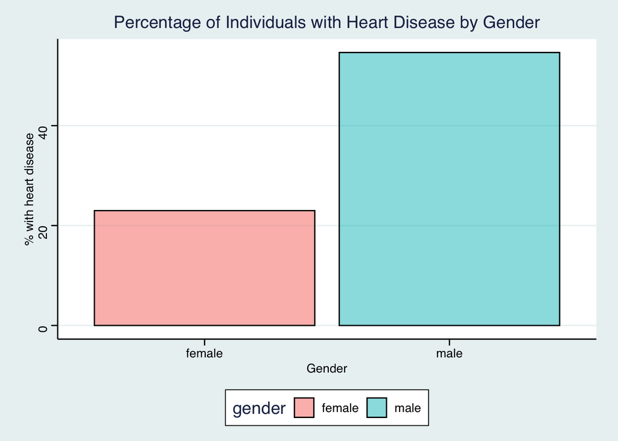

```r
heart_percent %>%
  ggplot(aes(x = gender, y = percent_heart_disease, fill = gender))+
  geom_col(color = "black", alpha = 0.5)+
  theme_stata()+
  labs(title = "Percentage of Individuals with Heart Disease by Gender", x  = "Gender", y = "% with heart disease")
```

Problem 7. (3 points) Is there a relationship between age and cholesterol levels? Make a plot that shows this relationship separated by gender (hint: use faceting or make two plots). Be sure to add a line of best fit (linear regression line). *There appears to be a slight positive relationship between age and cholesterol levels in this sample. This trend appears to be stronger in females than in males.*

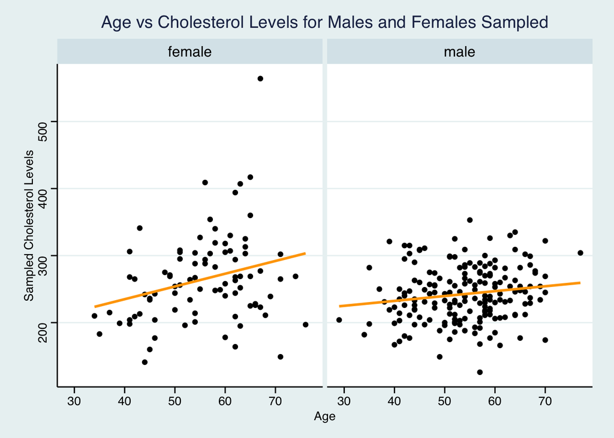

```r
heart %>%
  ggplot(aes(x = age, y = chol))+
  geom_point()+
  geom_smooth(method = lm, se = F, color = "orange")+
  facet_wrap(~gender, ncol = 2)+
  theme_stata()+
  labs(title = "Age vs Cholesterol Levels for Males and Females Sampled", x = "Age", y = "Sampled Cholesterol Levels")
```

Problem 8. (3 points) What is the range of resting blood pressure for participants by type of chest pain? Make a plot that shows this information.

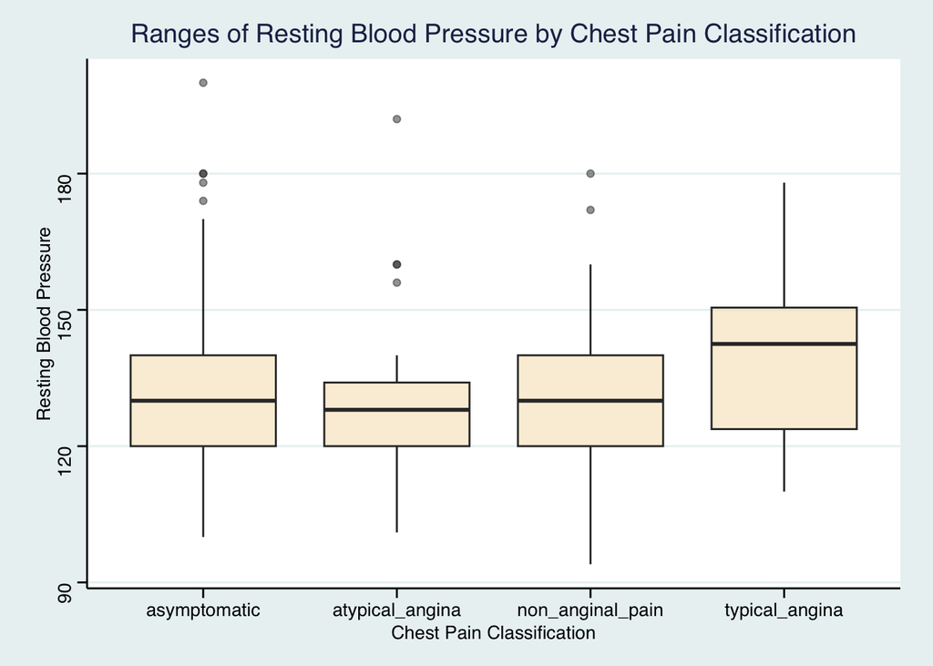

```r
heart %>%
  ggplot(aes(x = cp, y = trestbps))+
  geom_boxplot(fill = "wheat", alpha = 0.5)+
  theme_stata()+
  labs(title = "Ranges of Resting Blood Pressure by Chest Pain Classification", x = "Chest Pain Classification", y = "Resting Blood Pressure")
```

Problem 9. (4 points) What is the distribution of maximum heart rate achieved, separated by gender and whether or not the patient has heart disease? Make a plot that shows this information- you must use faceting.

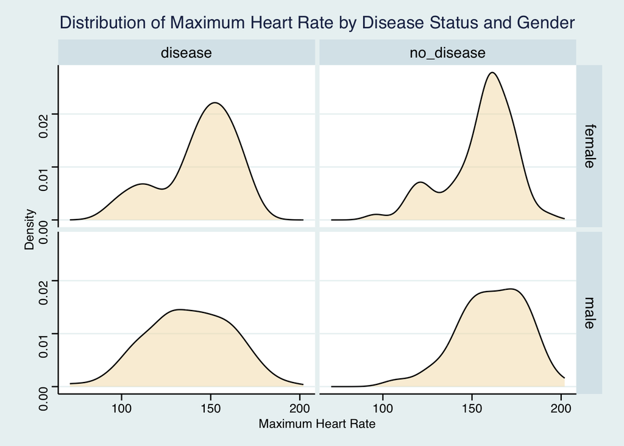

```r
heart %>%
  ggplot(aes(x = thalach))+
  geom_density(fill = "wheat", alpha = 0.5)+
  facet_grid(gender~target)+
  theme_stata()+
  labs(title = "Distribution of Maximum Heart Rate by Disease Status and Gender", x = "Maximum Heart Rate", y = "Density")
```

Problem 10. (4 points) What is the range of ST depression (oldpeak) by the number of major vessels colored by fluoroscopy (ca)? Make a plot that shows this relationship. (hint: should ca be a factor or numeric variable?)

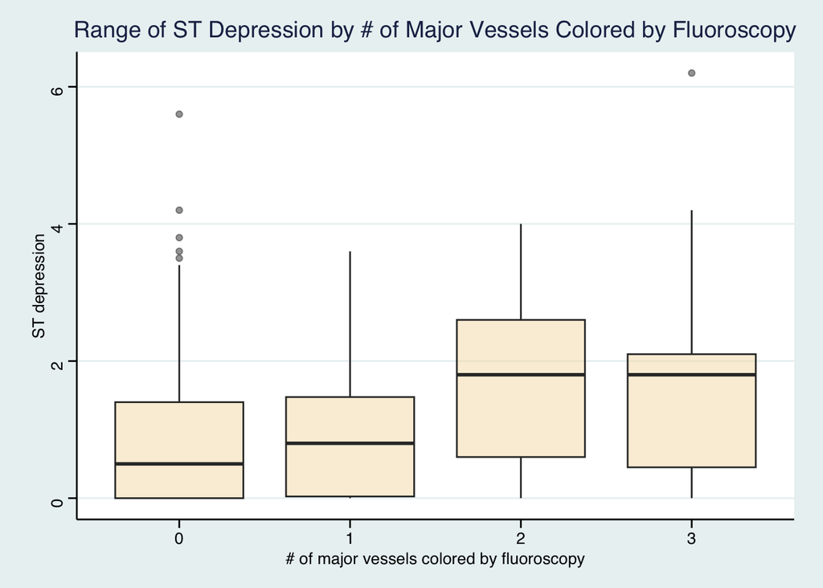

```r
heart %>%
  ggplot(aes(x = as.factor(ca), y = oldpeak))+
  geom_boxplot(fill = "wheat", alpha = 0.5)+
  theme_stata()+
  labs(title = "Range of ST Depression by # of Major Vessels Colored by Fluoroscopy", x = "# of major vessels colored by fluoroscopy", y = "ST depression")
```

Problem 11. (4 points) Is there an age group where we see increased prevalence of heart disease? Make a plot that shows the number of participants with and without heart disease by age group. *There appears to be an increased prevalence of heart disease in the 55-61 age group, which was the group ranging from the median to the 3rd quartile. I produced age groups that matched the 1st, 2nd, 3rd, and 4th quartiles for age.*

```r
summary(heart$age)
```

```
##    Min. 1st Qu.  Median    Mean 3rd Qu.    Max.
##   29.00   48.00   55.00   54.43   61.00   77.00
```

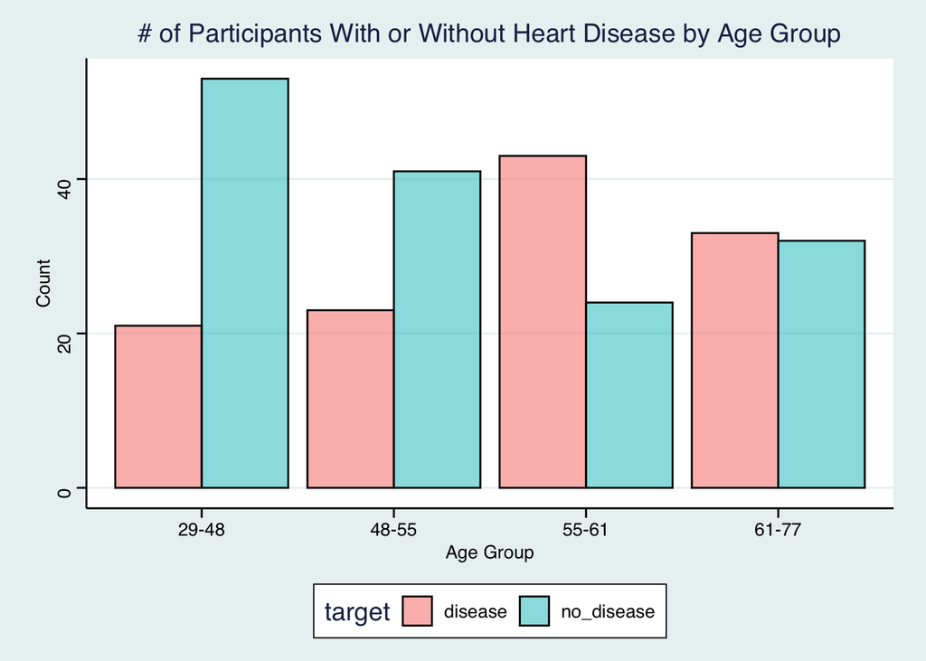

```r
heart %>%
  mutate(age_group = case_when(age <= 48 ~ "29-48",
                               age > 48 & age <= 55 ~ "48-55",
                               age > 55 & age <= 61 ~ "55-61",
                               age > 61 ~ "61-77")) %>%
  group_by(age_group, target) %>%
  summarize(status_age_group = n(), .groups = 'keep') %>%
  ggplot(aes(x = age_group, y = status_age_group, fill = target))+
  geom_col(pos = "dodge", color = "black", alpha = 0.5)+
  theme_stata()+
  labs(title = "# of Participants With or Without Heart Disease by Age Group", x = "Age Group", y = "Count")
```

## Submit the Midterm

1. Save your work and knit the .rmd file.
2. Open the .html file and “print” it to a .pdf file in Google Chrome (not Safari).
3. Go to the class Canvas page and open Gradescope.
4. Submit your .pdf file to the midterm assignment- be sure to assign the pages to the correct questions.
5. Commit and push your work to your repository.